# Reporting

## Agenda

1. Review advanced visualizations (and upgrade)
2. Customizing your reports
3. Dashboards

## Review of advanced visualizations

## Fixing the ‘jameson’ theme

```r
jameson <- theme_minimal() +
    theme(
      text = element_text(family = "Palatino", color = "gray25"),
      plot.subtitle = element_text(size = 12),
      plot.caption = element_text(color = "gray30"),
      plot.background = element_rect(fill = "gray95"),
      plot.margin = unit(c(5, 10, 5, 10), units = "mm")
    )
theme_set(jameson)

library(wesanderson)
scale_colour_discrete <- function(...) {
  scale_colour_manual(..., values = wes_palette(n=8, name="Moonrise3", type = "continuous"))
}
scale_fill_discrete <- function(...) {
  scale_fill_manual(..., values = wes_palette(n=8, name="Moonrise3", type = "continuous"))
}
```

## Works great for discrete colors.

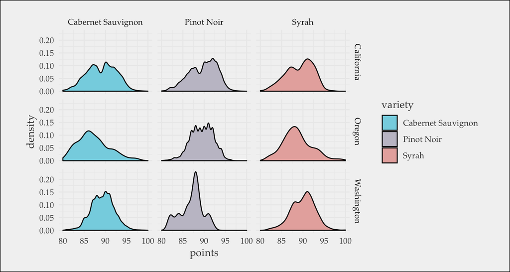

```r
wine %>%
  ggplot(aes(points, fill=variety))+
  geom_density()+
  facet_grid(province~variety)
```

## But what about continuous?

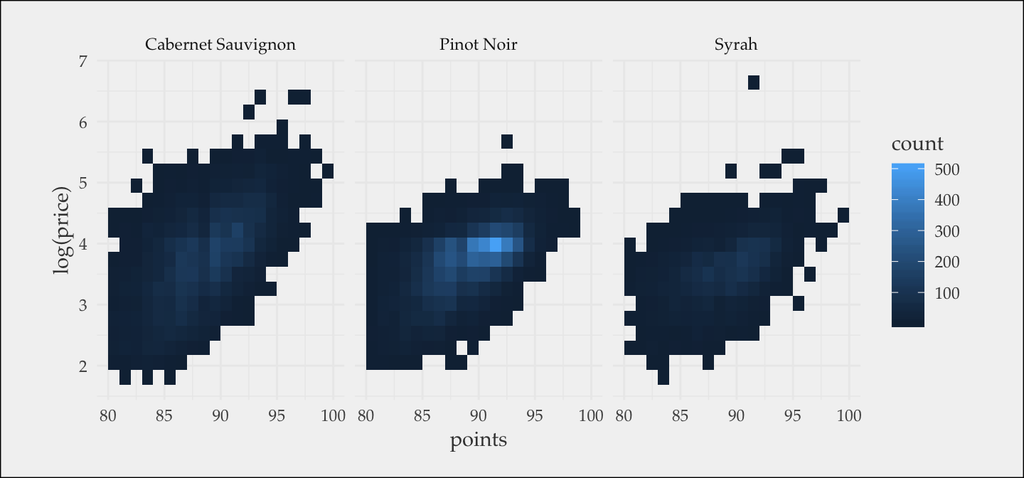

```r
wine %>%
  ggplot(aes(points,log(price)))+
  geom_bin2d(bins=20)+
  facet_grid(. ~ variety)
```

## Overriding the continuous function

```r
lc=wes_palette(n=2, name="Moonrise3")[[1]]
hc=wes_palette(n=2, name="Moonrise3")[[2]]
scale_colour_continuous <- function(...) {
  scale_colour_gradient(..., low = lc, high = hc)
}
scale_fill_continuous <- function(...) {
  scale_fill_gradient(..., low = lc, high = hc)
}
```

## Better

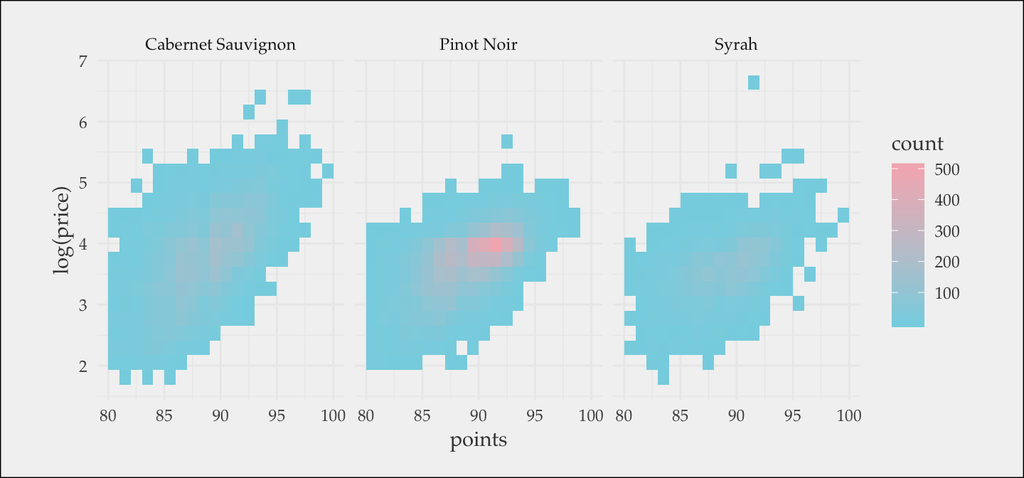

```r
wine %>%
  ggplot(aes(points,log(price)))+
  geom_bin2d(bins=20)+
  facet_grid(. ~ variety)
```

## Exercise (Part A)

1. Modify the below code to create your own theme
2. and set it globally

```r
jameson <- theme_minimal() +
    theme(
      text = element_text(family = "Palatino", color = "gray25"),
      plot.subtitle = element_text(size = 12),
      plot.caption = element_text(color = "gray30"),
      plot.background = element_rect(fill = "gray95"),
      plot.margin = unit(c(5, 10, 5, 10), units = "mm")
    )
theme_set(jameson)
```

## Exercise (Part B)

1. Create line plot of average points from 2000 to 2014
2. Faceted by province and variety

**Hint:** filter year > 1999 and < 2015 to get rid of random years

## Solution

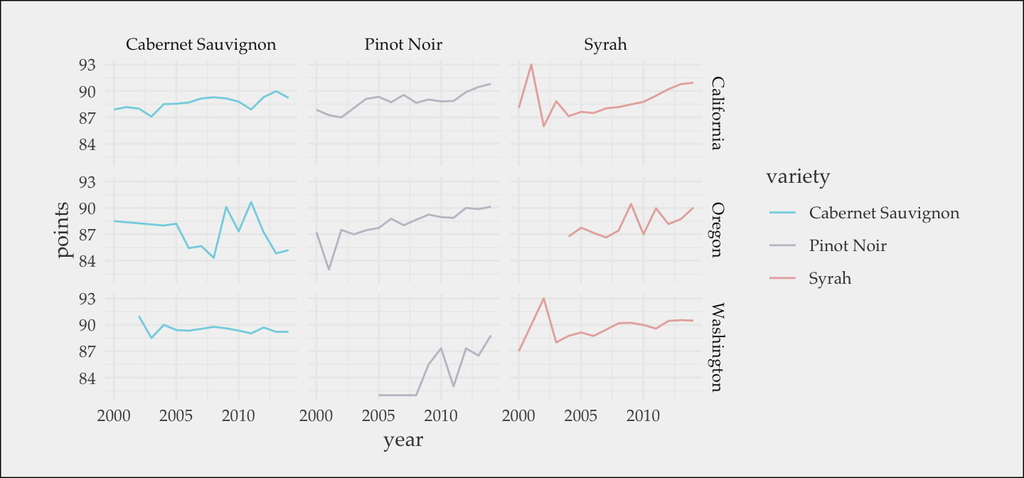

```r
wine %>%
  filter(year < 2015 & year > 1999) %>%
  group_by(province,variety,year) %>%
  summarise(points=mean(points)) %>%
  ggplot(aes(x = year, y = points, color=variety))+
  geom_line()+
  facet_grid(province~variety)
```

## Customizing your markdown reports

## TOC and Numbering

toc: true  
toc_depth: 2  
toc_float:  
collapsed: false  
smooth_scroll: true  
number_sections: true

## Tabs and Themes

- use {.tabset} within a section to create tabs
- themes come from https://bootswatch.com/3/
- highlight specifies the syntax highlighting style. Supported styles include default, tango, pygments, kate, monochrome, espresso, zenburn, haddock, breezedark, and textmate.

## Stylesheets, figures, and tables

You can create your own stylesheet if you wanna tweak stuff or override the whole thing. See **Session-10.css** for a few examples, or look at https://www.w3schools.com/cssref/ for the full reference.

You can set a variety of image features like width, height and caption. Default size is 5x7

You can set the default table rendering to *default*, *kable*, *tibble*, or *paged*

## Self-contained and templates

**self_contained: false**

Note that by default, all images etc are fully embedded in the html file… but they don’t need to be.

**template: quarterly_report.html**

See https://pandoc.org/MANUAL.html#templates for more information.

## Exercise

1. Create a new RMarkdown file (for your final report)
2. Add your custom theme to the setup chunk
3. Load your data in the setup chunk
4. Create an outline for your report with a TOC
5. Customize YAML options to your liking

output:  
html_document: toc: true  
toc_depth: 2  
toc_float:  
collapsed: true  
smooth_scroll: true  
number_sections: true  
theme: journal  
highlight: default  
css: Session-10.css  
fig_height: 5  
fig_width: 8.5  
df_print: kable

https://bookdown.org/yihui/rmarkdown/html-document.html

## Dashboards

## Flexdashboard

> install.packages(“flexdashboard”)

File–>new–>RMarkdown–>Templates

See the full documentation here: https://rmarkdown.rstudio.com/flexdashboard/using.html#overview

## Exercise

1. Create a new flexdashboard
2. View the documentation at the link below to pick your favorite layout
3. Create a dashboard from your final project data with
- three highlights
- three or more charts / tables

https://rmarkdown.rstudio.com/flexdashboard/using.html#overview

## Shiny (sorta bonus)

https://shiny.rstudio.com/gallery/